# trabajo practico m3- grupo 4

Grupo 4

2024-04-29

# Integrantes Grupo 4

- Graff Ailin
- Lopez Leandro
- Maglione Nicolas
- Sacchi Gina

#Cuerpo Docente

- Profesor: Dr. Ricardo Palma
- Asesor Pedagógico: Mg. Sebastián Miers
- Coordinadora Académica: Mg. Ing. Andrea Caballero
- Coordinadora Logística: Dra. Gabriela del Hoyo

# Introducción

## Analisis y evaluacion de la produccion de hidrocarburos no convencionales en Argentina, por YPF SA en el período de Marzo 2024

En el presente documento analisamos los datos de produccion de petroleo, gas y agua de pozos no convencionales de Argentina, presentados por YPF para el período de Marzo de 2024, en el que se abordaran diferentes analisis, evaluaciones y comparaciones que resultan de gran interes para cumplir con el objetivo de aplicar los conocimientos aprendidos durante el MÓDULO 3: Tecnologías Emergentes en los procesos Productivos - de la Diplomatura Universitaria en Gestión y Tecnologías para el desarrollo Convencional y No Convencional de Hidrocarburos.

# Materiales y Metodos

## base o conjunto de datos (datasets)

Con base en el dataset elegido, el objetivo es analizar los valores de producción de petroleo y gas de los pozos no convencionales de YPF para el mes de marzo 2024 y establecer la ubicacion de los pozos involucrados, asi como los sistemas de extraccion elegidos

El dataset de estudio es de nación, Producción de Petroleo y Gas No convencional del mes de marzo de 2024. Para el mismo se filtraron los valores, para que queden únicamente los pozos de YPF. Asi mismo, se eliminaron las columnas que no aportaban informacion, es decir que no contenian datos, y podrian suponer un conflicto para la realización de este trabajo.

La ubicación de esta tabla puede ser recuperado de: [Producción_NC_YPF](https://github.com/AilinGitHub/Entrega-final-G4/blob/main/Produccion%20NC%20YPF.csv)

```r
library(readr)
Produccion_NC_YPF <- read_delim("Produccion NC YPF.csv",
    delim = ";", escape_double = FALSE, col_types = cols(prod_gas = col_double(),
        coordenadax = col_number(), coordenaday = col_number()),
    trim_ws = TRUE)
View(Produccion_NC_YPF)
```

## Metdología - paquetes de datos a utilizar

Para el trabajo se emplearon las siguientes bibliotecas.

library(tidyverse) library(cluster) library(factoextra) library(ggplot2) library(maps) library(sf) library(leaflet) library(readr) library(readxl) library(stats) library(png) library(ucminf) library(orloca) library(leaflet.extras) library(dplyr) library(tinytex) library(sp) library(car)

```r
library(tidyverse)
library(cluster)
library(factoextra)
```

```r
library(ggplot2)
library(maps)
library(sf)
library(leaflet)
library(readr)
library(readxl)
library(stats)
library(png)
library(ucminf)
library(orloca)
library(leaflet.extras)
library(dplyr)
library(tinytex)
library(sp)
library(car)
```

## Asignación de variables

Primero asignamos al datasetcomo “datos” para simplificar el trabajo

```r
datos <- Produccion_NC_YPF
```

Asignamos variables a la produccion de gas y petroleo. Ademas del tipo de estado en el que se encuentra:

```r
ProdPet <-(datos$prod_pet)
ProdGas <-(datos$prod_gas)
TipoEstado <- c(datos$tipoestado)
Sigla <- c(datos$sigla)
```

asignamos las variables correspondientes al tipo de estado del pozo:

```r
EEF <- nrow(subset(datos, datos$tipoestado == "Extraccion Efectiva"))
ES <- nrow(subset(datos, datos$tipoestado == "En Estudio"))
PT <- nrow(subset(datos, datos$tipoestado == "Parado Transitoriamente"))
ARGP <- nrow(subset(datos, datos$tipoestado == "Parado Alta Relacion Gas/Petroleo"))
EER <- nrow(subset(datos, datos$tipoestado == "En Espera de Reparacion"))
EIE <- nrow(subset(datos, datos$tipoestado == "En Inyeccion Efectiva"))
AT <- nrow(subset(datos, datos$tipoestado == "Abandono Temporario"))
A <- nrow(subset(datos, datos$tipoestado == "Abandonado"))
EE <- nrow(subset(datos, datos$tipoestado == "En Estudio"))
AA <- nrow(subset(datos, datos$tipoestado == "A Abandonar"))
ER <- nrow(subset(datos, datos$tipoestado == "En Reparacion"))
ERG <- nrow(subset(datos, datos$tipoestado == "En Reserva de Gas"))
RRSA <- nrow(subset(datos, datos$tipoestado == "En Reserva para Recup. Sec./Asist."))
OCI <- nrow(subset(datos, datos$tipoestado == "Otras Situacion Inactivo"))
```

valores promedio

```r
prom_pet <- mean(Produccion_NC_YPF$prod_pet)
prom_gas <- mean(Produccion_NC_YPF$prod_gas)
prom_agua <- mean(Produccion_NC_YPF$prod_agua)
```

Para el desarrollo del analisis de profundidades

```r
tipo_ext <- c(datos$tipoextraccion)

tipo_pz <- c(datos$tipopozo)

profundidad <- c(datos$profundidad)

area <- c(datos$areapermisoconcesion)

prov <- c(datos$provincia)

sub_tipo_rec <- c(datos$sub_tipo_recurso)
```

se establecen nuevas variables para la creacion de un nuevo data.frame que servira al analisis de la produccion.

```r
tipo_de_extraccion<- C(datos$tipoextraccion)

prod.tipoextraccion<- data.frame(tipo_de_extraccion,ProdPet,ProdGas)

Surgencia_Natural_Pet<- sum(subset(prod.tipoextraccion$ProdPet,tipo_de_extraccion=="Surgencia Natural"))

Plunger_Lift_Pet<- sum(subset(prod.tipoextraccion$ProdPet,tipo_de_extraccion=="Plunger Lift"))

Bombeo_Mecanico_Pet<- sum(subset(prod.tipoextraccion$ProdPet,tipo_de_extraccion=="Bombeo Mecanico"))

Gas_Lift_Pet<- sum(subset(prod.tipoextraccion$ProdPet,tipo_de_extraccion=="Gas Lift"))

## se calculo el total de produccion de petroleo por cada metodo aplicado


Surgencia_Natural_gas<- sum(subset(prod.tipoextraccion$ProdGas,tipo_de_extraccion=="Surgencia Natural"))

Plunger_Lift_gas<- sum(subset(prod.tipoextraccion$ProdGas,tipo_de_extraccion=="Plunger Lift"))

Bombeo_Mecanico_gas<- sum(subset(prod.tipoextraccion$ProdGas,tipo_de_extraccion=="Bombeo Mecanico"))

Gas_Lift_gas<- sum(subset(prod.tipoextraccion$ProdGas,tipo_de_extraccion=="Gas Lift"))

## se calculo el total de produccion de gas por cada metodo aplicado
```

para el desarrollo de la parte geográfica:

```r
# Damos a conocer las areas en donde se encuentran los pozos NC

AGUADA_DE_LA_ARENA <- c(length (which (area == "AGUADA DE LA ARENA")))

AGUADA_DEL_CHANAR <- c(length (which (area == "AGUADA DEL CHANAR")))

AL_NORTE_DE_LA_DORSA <- c(length (which (area == "AL NORTE DE LA DORSAL")))

BAJO_DEL_TORO <- c(length (which (area == "BAJO DEL TORO")))

BAJO_DEL_TORO_NORTE <- c(length (which (area == "BAJO DEL TORO NORTE")))

BANDURRIA_SUR <- c(length (which (area == "BANDURRIA SUR")))

CERRO_ARENA <- c(length (which (area == "CERRO ARENA")))

CERRO_LAS_MINAS <- c(length (which (area == "CERRO LAS MINAS")))

CERRO_MANRIQUE <- c(length (which (area == "CERRO MANRIQUE")))

CHIUIDO_DE_LA_SIERRA_NEGRAS <- c(length (which (area == "CHIUIDO DE LA SIERRA NEGRAS")))

CN_VII_A <- c(length (which (area == "CN VII A")))

DADIN <- c(length (which (area == "DADIN")))

EL_OREJANO <- c(length (which (area == "EL OREJANO")))

ESTACION_FERNADEZ_ORO <- c(length (which (area == "ESTACION FERNADEZ ORO")))

FILO_MORADO <- c(length (which (area == "FILO MORADO")))

LA_AMARGA_CHICA <- c(length (which (area == "LA AMARGA CHICAL")))

LA_RIBERA_BLOQUE_I <- c(length (which (area == "LA RIBERA BLOQUE I")))

LA_RIBERA_BLOQUE_II <- c(length (which (area == "LA RIBERA BLOQUE II")))

LAS_MANADAS <- c(length (which (area == "LAS MANADAS")))

LAS_TACANAS <- c(length (which (area == "LAS TACANAS")))

LOMA_AMARILLA_SUR <- c(length (which (area == "LOMA AMARILLA SUR")))

LOMA_CAMPANA <- c(length (which (area == "LOMA CAMPANA")))

LOMA_DEL_MOLLE <- c(length (which (area == "LOMA DEL MOLLE")))

LOMA_LA_LATA_SIERRA_BARROSA <- c(length (which (area == "LOMA LA LATA-SIERRA BARROSA")))

LOS_CALDENES <- c(length (which (area == "LOS CALDENES")))

OCTOGONO <- c(length (which (area == "OCTOGONO")))

PASO_DE_LAS_BARDAS_NORTE <- c(length (which (area == "PASO DE LAS BARDAS NORTE")))

RINCON_DEL_MANGRULLO <- c(length (which (area == "RINCON DEL MANGRULLO")))

RIO_NEUQUEN <- c(length (which (area == "RIO Neuquen")))

VALLE_DEL_RIO_GRANDE <- c(length (which (area == "VALLE DEL RIO GRANDE")))
```

```r
Neuquen <- length (which (prov == "Neuquen"))

Rio_Negro <- length (which (prov == "Rio Negro"))

Mendoza <- length (which (prov == "Mendoza"))
```

para graficos de torta

```r
EE_torta <- nrow(subset(datos, datos$tipoestado == "Extraccion Efectiva"))


ES_torta <- nrow(subset(datos, datos$tipoestado == "En Estudio"))


PT_torta <- nrow(subset(datos, datos$tipoestado == "Parado Transitoriamente"))
```

```r
SHALE <- c(length (which (sub_tipo_rec == "SHALE")))
TIGHT <- c(length (which (sub_tipo_rec == "TIGHT")))
```

# Desarrollo

## Casos de estudio

El caso de estudio son las concesiones operadas por YPF SA, para la produccion de hidrocarburos no convencionales durante el mes de marzo de 2024

## Navegación y Manipulacion de datos.

A partir del dataset, comenzamos a utilizar algunas de las funciones aprendidas en el desarrollo del curso, para explorar el contenido de la tabla.

1. Comenzaremos con el encabezado de nuestra tabla utilizando el comando “names()”

   De los siguientes datos, podemos identificar cuales analizaremos a lo largo del trabajo. En este caso, vemos que los datos de producción de petróloeo y gas son los de mayor interés.

```r
names(datos)
```

```
##  [1] "idempresa"              "anio"                   "mes"
##  [4] "idpozo"                 "prod_pet"               "prod_gas"
##  [7] "prod_agua"              "tef"                    "tipoextraccion"
## [10] "tipoestado"             "tipopozo"               "idusuario"
## [13] "empresa"                "sigla"                  "formprod"
## [16] "profundidad"            "formacion"              "idareapermisoconcesion"
## [19] "areapermisoconcesion"   "idareayacimiento"       "areayacimiento"
## [22] "cuenca"                 "provincia"              "coordenadax"
## [25] "coordenaday"            "tipo_de_recurso"        "clasificacion"
## [28] "subclasificacion"       "sub_tipo_recurso"
```

2. Para ver las dimensiones (filas y columnas) colocamos el comando dim()

```r
dim(datos)
```

```
## [1] 2108   29
```

de la cual obtenemos que la cantidad de pozos declarados por YPF son 2108, en el período de estudio.

3. Cabecera y pie de la tabla

Cabecera.

```r
head(datos)
```

```
## # A tibble: 6 × 29
##   idempresa  anio   mes idpozo prod_pet prod_gas prod_agua   tef tipoextraccion
##   <chr>     <dbl> <dbl>  <dbl>    <dbl>    <dbl>     <dbl> <dbl> <chr>
## 1 YPF        2024     3  75605     0         0        0        0 Plunger Lift
## 2 YPF        2024     3  75604     0         0        0        0 Plunger Lift
## 3 YPF        2024     3  72233    10.6     208.       0       31 Surgencia Natu…
## 4 YPF        2024     3  72232     9.84    427.      43.3     31 Surgencia Natu…
## 5 YPF        2024     3  72228     1.98     46.2      5.05    30 Surgencia Natu…
## 6 YPF        2024     3  72206     0         0        0        0 Surgencia Natu…
## # ℹ 20 more variables: tipoestado <chr>, tipopozo <chr>, idusuario <dbl>,
## #   empresa <chr>, sigla <chr>, formprod <chr>, profundidad <dbl>,
## #   formacion <chr>, idareapermisoconcesion <chr>, areapermisoconcesion <chr>,
## #   idareayacimiento <chr>, areayacimiento <chr>, cuenca <chr>,
## #   provincia <chr>, coordenadax <dbl>, coordenaday <dbl>,
## #   tipo_de_recurso <chr>, clasificacion <chr>, subclasificacion <chr>,
## #   sub_tipo_recurso <chr>
```

Pie.

```r
tail(datos)
```

```
## # A tibble: 6 × 29
##   idempresa  anio   mes idpozo prod_pet prod_gas prod_agua   tef tipoextraccion
##   <chr>     <dbl> <dbl>  <dbl>    <dbl>    <dbl>     <dbl> <dbl> <chr>
## 1 YPF        2024     3 115725        0       0        0       0 Surgencia Natu…
## 2 YPF        2024     3 115664        0       0        0       0 Bombeo Mecanico
## 3 YPF        2024     3 114889        0       0        0       0 Surgencia Natu…
## 4 YPF        2024     3 114888        0     442.      28.3    31 Surgencia Natu…
## 5 YPF        2024     3 114880        0       0        0       0 Surgencia Natu…
## 6 YPF        2024     3 114867        0       0        0       0 Surgencia Natu…
## # ℹ 20 more variables: tipoestado <chr>, tipopozo <chr>, idusuario <dbl>,
## #   empresa <chr>, sigla <chr>, formprod <chr>, profundidad <dbl>,
## #   formacion <chr>, idareapermisoconcesion <chr>, areapermisoconcesion <chr>,
## #   idareayacimiento <chr>, areayacimiento <chr>, cuenca <chr>,
## #   provincia <chr>, coordenadax <dbl>, coordenaday <dbl>,
## #   tipo_de_recurso <chr>, clasificacion <chr>, subclasificacion <chr>,
## #   sub_tipo_recurso <chr>
```

**Maxima Produccion de petroleo**

Ubicacion de la fila:

```r
which.max(Produccion_NC_YPF$prod_pet)
```

```
## [1] 68
```

cuyo valor correspondiente es:

```r
Produccion_NC_YPF$prod_pet[68]
```

```
## [1] 7390.03
```

**Maxima Produccion de gas**

Ubicacion de la fila:

```r
which.max(Produccion_NC_YPF$prod_gas)
```

```
## [1] 148
```

cuyo valor correspondiente es:

```r
Produccion_NC_YPF$prod_gas[148]
```

```
## [1] 14212.68
```

**Minima Produccion petroleo**

Ubicacion de la fila:

```r
which.min(Produccion_NC_YPF$prod_pet)
```

```
## [1] 1
```

cuyo valor corresponde a

```r
Produccion_NC_YPF$prod_pet[1]
```

```
## [1] 0
```

Para el caso de gas el valor tambien devolverá 0 ya que toma el valor de pozos sin produccion actualmente

## Análisis de la produccion.

se puede observar en el siguiente gráfico la produccion total de petroleo y gas de cada pozo, clasificado por tipo de extraccion

```r
tipo_de_extraccion<- C(datos$tipoextraccion)

prod.tipoextraccion<- data.frame(tipo_de_extraccion,ProdPet,ProdGas)

head(prod.tipoextraccion)
```

```
##   tipo_de_extraccion ProdPet ProdGas
## 1       Plunger Lift    0.00    0.00
## 2       Plunger Lift    0.00    0.00
## 3  Surgencia Natural   10.65  208.12
## 4  Surgencia Natural    9.84  427.42
## 5  Surgencia Natural    1.98   46.16
## 6  Surgencia Natural    0.00    0.00
```

una forma de representarlo mediante grafico de coordenadas polares:

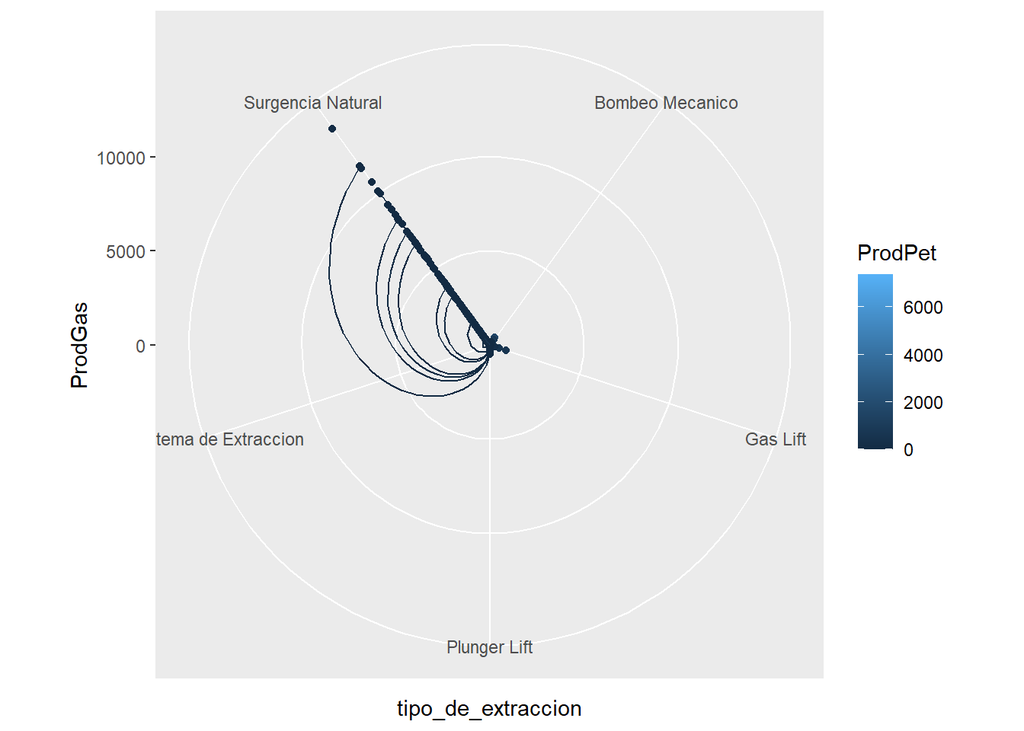

```r
ggplot(prod.tipoextraccion, aes(x = tipo_de_extraccion, y = ProdGas, col = ProdPet, group = ProdPet)) + geom_point() + geom_line() + coord_polar()
```

total de produccion por sistema de extraccion:

```r
# se crea dataframe para grafico de radar

sistema_extraccion<- c("Surgencia Natural","Plunger Lift","Bombeo Mecanico","Gas Lift")

total_pet_por_sistema<- c(Surgencia_Natural_Pet,Plunger_Lift_Pet,Bombeo_Mecanico_Pet,Gas_Lift_Pet)

total_gas_por_sistema<- c(Surgencia_Natural_gas,Plunger_Lift_gas,Bombeo_Mecanico_gas,Gas_Lift_gas)

prod.tipoextraccion<- data.frame(sistema_extraccion,total_pet_por_sistema,total_gas_por_sistema)

head(prod.tipoextraccion)
```

```
##   sistema_extraccion total_pet_por_sistema total_gas_por_sistema
## 1  Surgencia Natural             928589.75             696101.57
## 2       Plunger Lift              13246.17              37845.47
## 3    Bombeo Mecanico              88500.36              16030.89
## 4           Gas Lift               3662.53               3122.71
```

graficamente:

```
## `geom_line()`: Each group consists of only one observation.
## ℹ Do you need to adjust the group aesthetic?
```

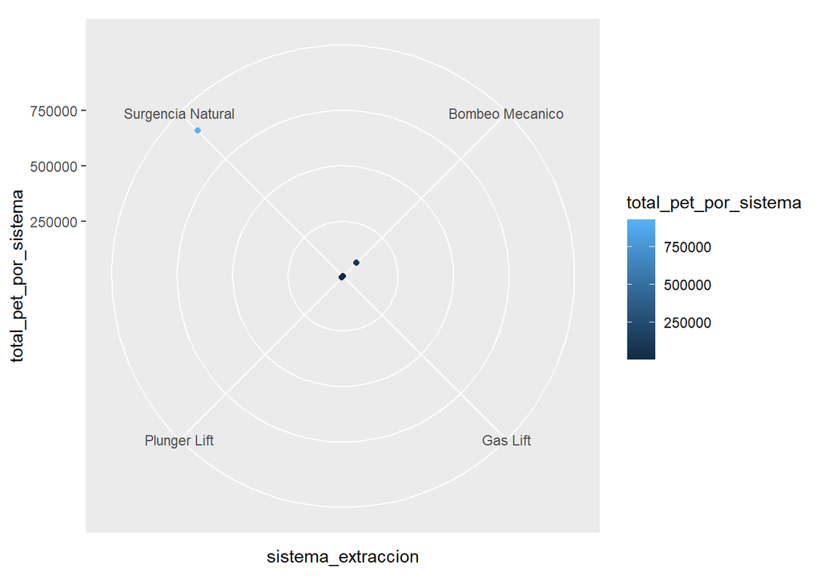

```r
ggplot(prod.tipoextraccion, aes(x = sistema_extraccion, y = total_pet_por_sistema, col = total_pet_por_sistema, group = total_pet_por_sistema)) + geom_point() + geom_line() + coord_polar()
```

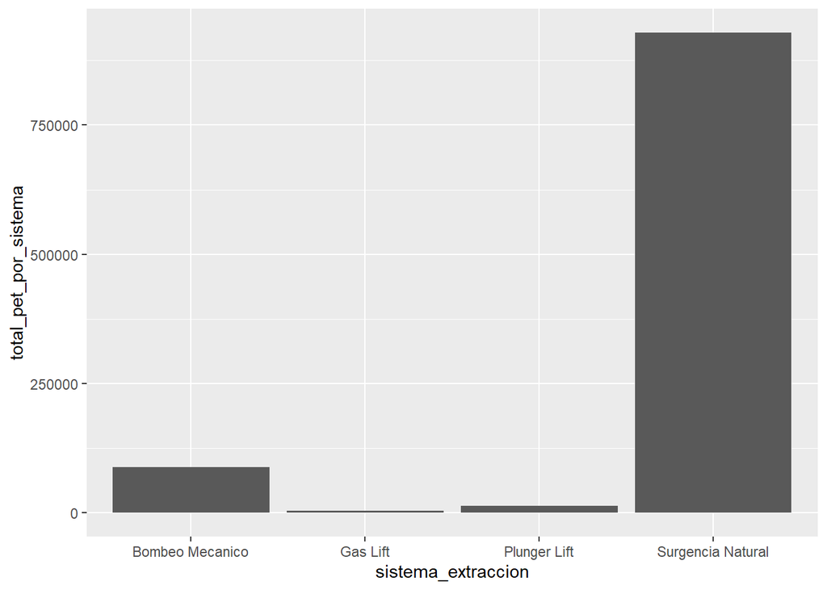

```r
par(mfrow =c(1,2))
ggplot(prod.tipoextraccion,aes(x=sistema_extraccion,y= total_pet_por_sistema))+geom_bar(stat="identity")
```

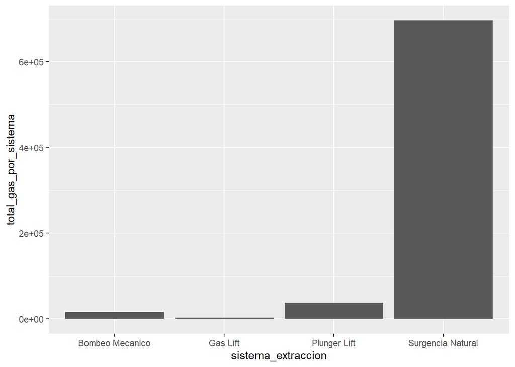

```r
ggplot(prod.tipoextraccion,aes(x=sistema_extraccion,y= total_gas_por_sistema))+geom_bar(stat="identity")
```

Tambien Podemos definir la cantidad de pozos en funcion a su tipo de estado:

```r
pozos_por_estado<-data.frame(EEF, ES, RRSA, ARGP, PT, ERG, EER, ER, EIE , AT, EE, OCI, A, AA)

pozos_por_estado
```

```
##    EEF  ES RRSA ARGP  PT ERG EER ER EIE AT  EE OCI  A AA
## 1 1657 128    2    1 158  23  30  6  10 10 128   3 22 58
```

donde: EEF = Extraccion Efectiva ES = En Estudio PT = Parado Transitoriamente ARGP = Parado Alta Relacion Gas/Petroleo EER = En Espera de Reparacion EIE = En Inyeccion Efectiva AT = Abandono Temporario  
A = Abandonado EE = En Estudio AA = A Abandonar ER = En Reparacion ERG = En Reserva de Gas RRSA = En Reserva para Recup. Sec./Asist. OCI = Otras Situacion Inactivo

Podemos obserbar a continuación, la produccion de petroleo y gas de estos pozos. Lo siguiente es un extracto de la tabla 2, la cual se muestra completa en la seccion correspondiente

```r
dataf_tipoestado <- data.frame(Sigla, TipoEstado, ProdGas, ProdPet)

head(dataf_tipoestado,n=4L)
```

```
##             Sigla              TipoEstado ProdGas ProdPet
## 1 YPF.Nq.RN.xp-58              En Estudio    0.00    0.00
## 2 YPF.Nq.RN.xp-58 Parado Transitoriamente    0.00    0.00
## 3   PC.Nq.RN-1040     Extraccion Efectiva  208.12   10.65
## 4   PC.Nq.RN-1039     Extraccion Efectiva  427.42    9.84
```

```r
tail(dataf_tipoestado,n=4L)
```

```
##                  Sigla          TipoEstado ProdGas ProdPet
## 2105 YPF.Nq.CuM.e-5(I) Extraccion Efectiva    0.00       0
## 2106 YPF.Nq.CuM.e-5(I) Extraccion Efectiva  441.93       0
## 2107    YPF.Nq.CuM.a-3 Extraccion Efectiva    0.00       0
## 2108    YPF.Nq.CuM.a-8          En Estudio    0.00       0
```

Tambien podemos clasificar segun: *sub tipo de pozo*

```r
data.frame(SHALE, TIGHT)
```

```
##   SHALE TIGHT
## 1  1377   731
```

graficamente:

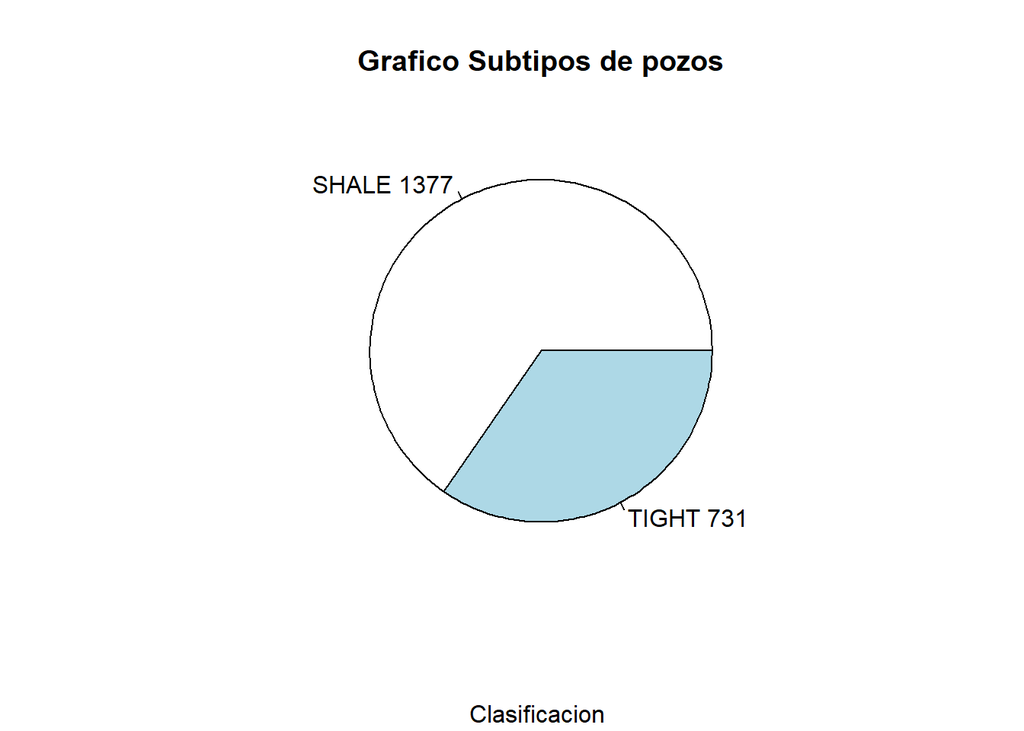

```r
# Determinamos la diferencia del sub tipo de recurso
subtipo <- c(SHALE, TIGHT)
etiquetas_subtipo2 <- c("SHALE", "TIGHT")
etiquetas_subtipo <- paste(etiquetas_subtipo2, subtipo)

pie(subtipo, etiquetas_subtipo,
    main = "Grafico Subtipos de pozos",
    sub = "Clasificacion ")
```

### Produccion de petroleo y gas

- Producción total Pet NC - YPF

```r
sum(ProdPet)
```

```
## [1] 1033999
```

- Obtenemos los principales datos estadísticos con el comando summary

```r
summary(ProdPet)
```

```
##    Min. 1st Qu.  Median    Mean 3rd Qu.    Max.
##    0.00    0.00   14.75  490.51  305.29 7390.03
```

de estos datos, se observa que la máxima producción de petróleo de uno de los pozos es de 7390.03 m3/d mientras que la menor es de 0 (pozos parados). La producción promedio del conjunto de pozos no convencionales para el mes de marzo fue de 490m3/d.

- Producción total gas NC - YPF

```r
sum(ProdGas)
```

```
## [1] 753100.6
```

```r
summary(ProdGas)
```

```
##     Min.  1st Qu.   Median     Mean  3rd Qu.     Max.
##     0.00     2.30    65.58   357.26   256.74 14212.68
```

A continuación, se puede observar los gráficos analizando estos valores:

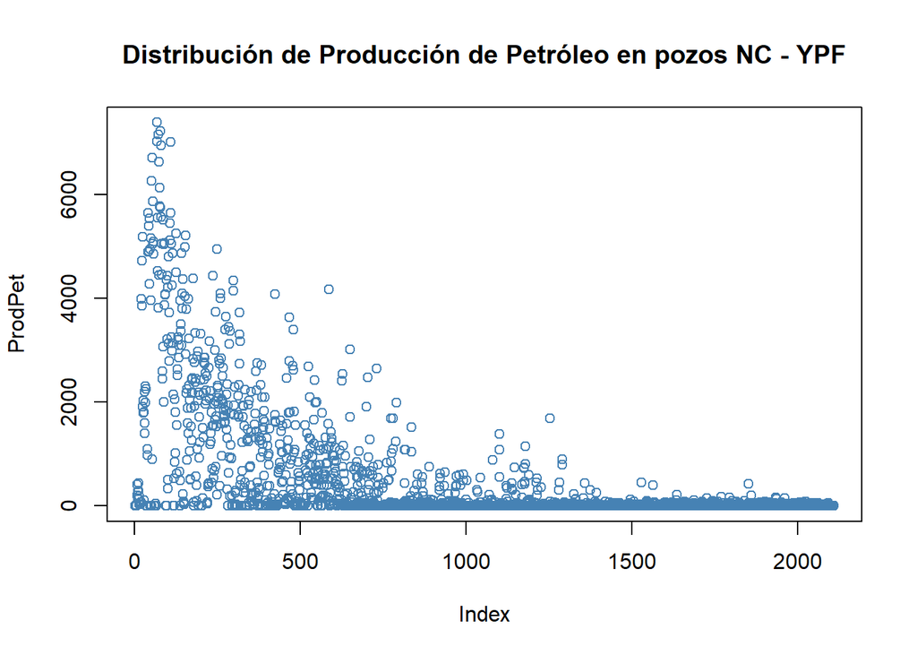

```r
plot(ProdPet, col='steelblue', ,, main = "Distribución de Producción de Petróleo en pozos NC - YPF")
```

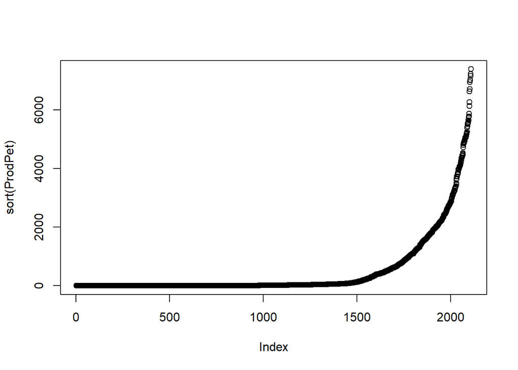

```r
plot(sort(ProdPet))
```

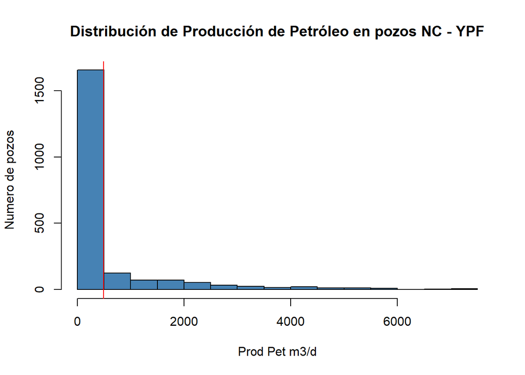

```r
hist(ProdPet, col='steelblue', xlab = 'Prod Pet m3/d', ylab = 'Numero de pozos', main = "Distribución de Producción de Petróleo en pozos NC - YPF")
abline(v = mean(ProdPet), col='red', lwd = 1)
```

## Pozos en extraccion efectiva

Los pozos cuentan con diferentes estados dentro de los cuales destacan:

```r
data.frame(EEF, ES, PT)
```

```
##    EEF  ES  PT
## 1 1657 128 158
```

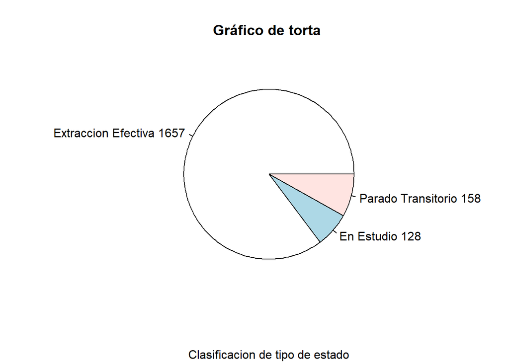

```r
tipoestado1 <- c(EEF, ES, PT)
etiquetas_2 <- c("Extraccion Efectiva", "En Estudio", "Parado Transitorio")
etiquetas <- paste(etiquetas_2, tipoestado1)

pie(tipoestado1, etiquetas,
    main = "Gráfico de torta ",
    sub = "Clasificacion de tipo de estado")
```

Se presentan los datos por tipo de estado, mostrando:

corte superior e inferior de la tabla:

```r
dataf_tipoestado <- data.frame(TipoEstado, ProdGas, ProdPet)
head(dataf_tipoestado,n=4L)
```

```
##                TipoEstado ProdGas ProdPet
## 1              En Estudio    0.00    0.00
## 2 Parado Transitoriamente    0.00    0.00
## 3     Extraccion Efectiva  208.12   10.65
## 4     Extraccion Efectiva  427.42    9.84
```

```r
tail(dataf_tipoestado,n=4L)
```

```
##               TipoEstado ProdGas ProdPet
## 2105 Extraccion Efectiva    0.00       0
## 2106 Extraccion Efectiva  441.93       0
## 2107 Extraccion Efectiva    0.00       0
## 2108          En Estudio    0.00       0
```

se filtran los datos por extraccion efectiva:

corte superior e inferior de la tabla:

```r
ExtraccionEfectiva <- subset(dataf_tipoestado, TipoEstado == "Extraccion Efectiva")
head(ExtraccionEfectiva,n=5L)
```

```
##            TipoEstado ProdGas ProdPet
## 3 Extraccion Efectiva  208.12   10.65
## 4 Extraccion Efectiva  427.42    9.84
## 5 Extraccion Efectiva   46.16    1.98
## 7 Extraccion Efectiva   21.46  198.38
## 8 Extraccion Efectiva   43.39  409.14
```

```r
tail(ExtraccionEfectiva,n=5L)
```

```
##               TipoEstado ProdGas ProdPet
## 2100 Extraccion Efectiva   94.77     1.1
## 2101 Extraccion Efectiva   65.95     0.7
## 2105 Extraccion Efectiva    0.00     0.0
## 2106 Extraccion Efectiva  441.93     0.0
## 2107 Extraccion Efectiva    0.00     0.0
```

De esta manera los datos reales de produccion, teniendo solo en cuenta los pozos en extraccion efectiva son de acuerdo al siguiente grafico

- Producción Pet

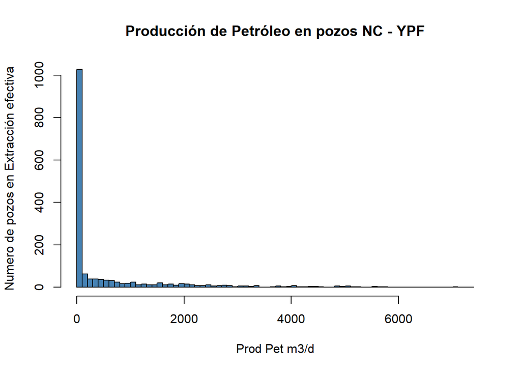

```r
hist(ExtraccionEfectiva$ProdPet, breaks = 100, col='steelblue', xlab = 'Prod Pet m3/d', ylab = 'Numero de pozos en Extracción efectiva', main = "Producción de Petróleo en pozos NC - YPF")
```

- Producción Gas

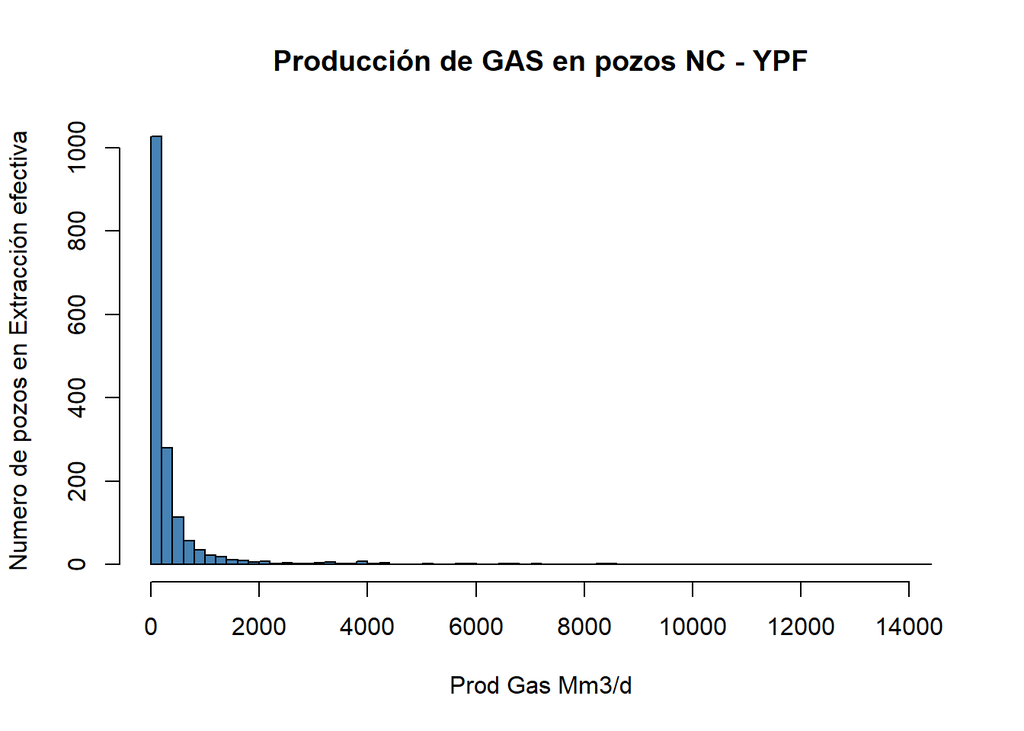

```r
hist(ExtraccionEfectiva$ProdGas, breaks = 100, col='steelblue', xlab = 'Prod Gas Mm3/d', ylab = 'Numero de pozos en Extracción efectiva', main = "Producción de GAS en pozos NC - YPF")
```

*Estadisticas reales de produccion de petroleo y gas*

de esta manera tambien los datos estadisticos se acercan mejor a los valores reales.

estadisticas para produccion de petroleo:

```r
summary(ExtraccionEfectiva$ProdPet)
```

```
##    Min. 1st Qu.  Median    Mean 3rd Qu.    Max.
##    0.00    3.45   38.17  624.02  617.39 7390.03
```

de estos datos, se observa que la máxima producción de petróleo de uno de los pozos es de 7390,03 m3/d mientras que la menor es de 0 (pozos parados). La producción promedio del conjunto de pozos no convencionales para el mes de marzo fue de 624,02 m3/d.

podemos comparar estos valores con el promedio de produccion de petroleo, teniendo en cuenta todo tipo de estado de pozo que es:

```r
prom_pet
```

```
## [1] 490.5118
```

estadisticas para produccion de gas:

```r
summary(ExtraccionEfectiva$ProdGas)
```

```
##     Min.  1st Qu.   Median     Mean  3rd Qu.     Max.
##     0.00    29.94   120.83   454.50   323.48 14212.68
```

de estos datos, se observa que la máxima producción de gas de uno de los pozos es de 14212,68 m3/d mientras que la menor es de 0 (pozos parados). La producción promedio del conjunto de pozos no convencionales para el mes de marzo fue de 454,5 m3/d.

podemos comparar estos valores con el promedio de produccion de gas, teniendo en cuenta todo tipo de estado de pozo que es:

```r
prom_gas
```

```
## [1] 357.2584
```

Asi mismo podemos comparar estos valores con la produccion de agua:

```r
prom_agua
```

```
## [1] 154.9882
```

de esta manera comparamos:

```r
prom_R_Pet<- mean(ExtraccionEfectiva$ProdPet)
prom_R_gas<- mean(ExtraccionEfectiva$ProdGas)
rotulos_prom_prod <- c("prom_pet","prom_R_Pet","prom_gas","prom_R_gas","prom_agua")
promedios_prod<- c(prom_pet,prom_R_Pet,prom_gas,prom_R_gas,prom_agua)

compar.prom <- data.frame(rotulos_prom_prod,promedios_prod)
compar.prom
```

```
##   rotulos_prom_prod promedios_prod
## 1          prom_pet       490.5118
## 2        prom_R_Pet       624.0186
## 3          prom_gas       357.2584
## 4        prom_R_gas       454.4965
## 5         prom_agua       154.9882
```

graficamente:

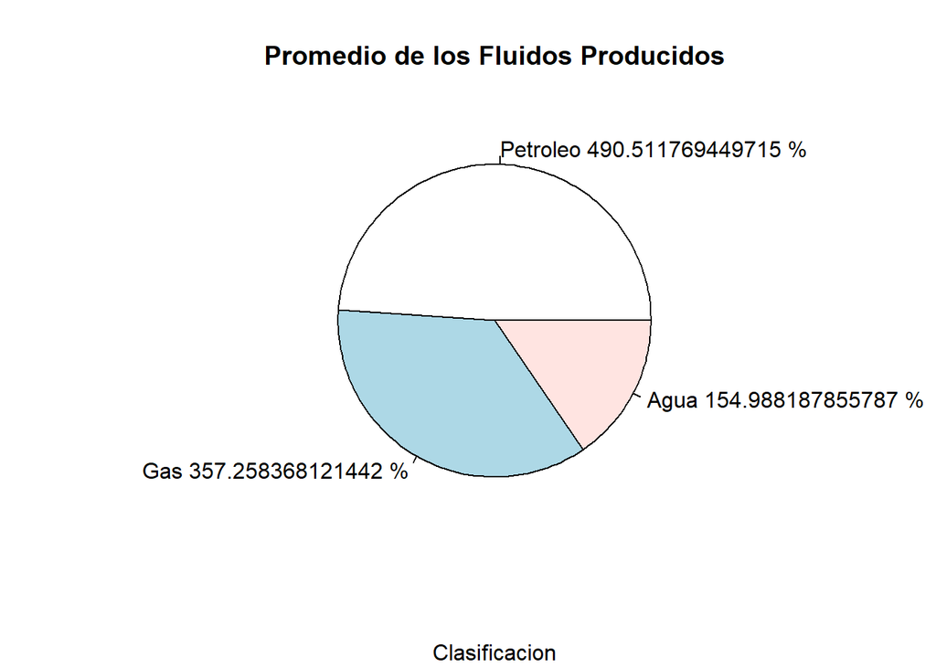

```r
promedios_grafico <- c(prom_pet, prom_gas, prom_agua)
etiquetas_compar_promedios <- c("Petroleo", "Gas", "Agua")
etiquetas_compar_promedios <- paste(etiquetas_compar_promedios, promedios_grafico)
etiquetas_compar_promedios <- paste(etiquetas_compar_promedios, "%", sep = " ")
pie(promedios_grafico, etiquetas_compar_promedios,
    main = "Promedio de los Fluidos Producidos",
    sub = "Clasificacion")
```

distribucion normal:

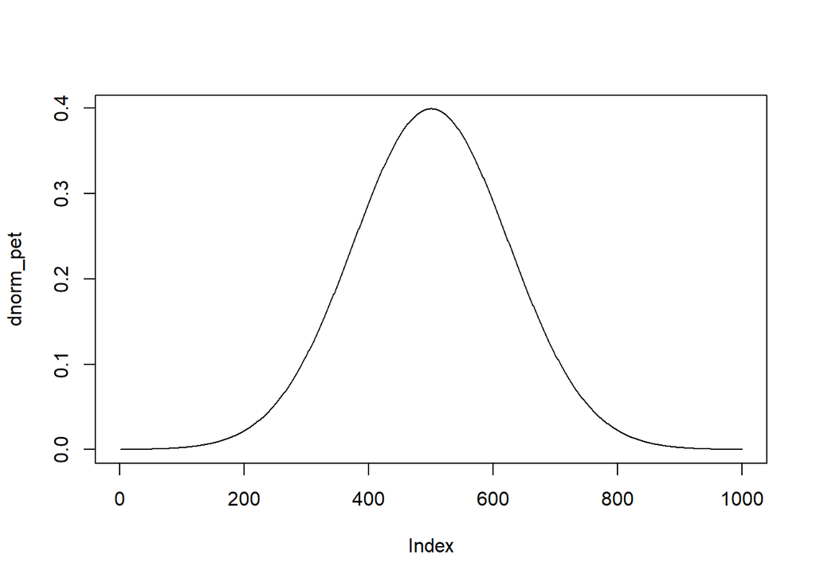

```r
x <- seq(-4, 4, length.out=1000)
dnorm_pet <- dnorm(x)
plot(dnorm_pet, type="l")
```

*ploteos de densidad*

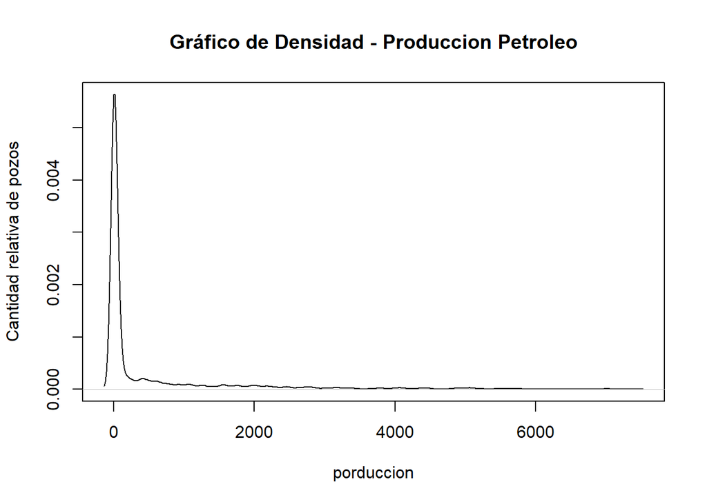

```r
plot(density(ProdPet), main = "Gráfico de Densidad - Produccion Petroleo", ylab="Cantidad relativa de pozos",xlab="porduccion")
```

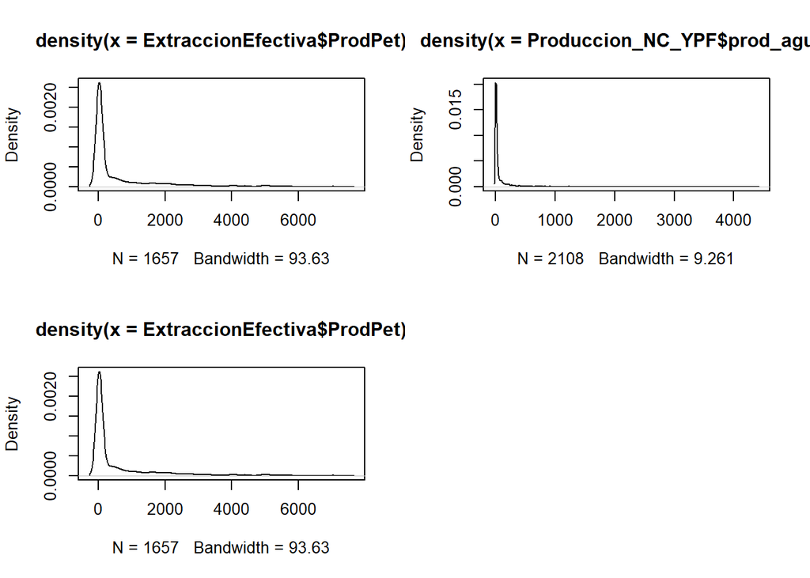

```r
par(mfcol=c(2,2))
plot(density(ExtraccionEfectiva$ProdPet))
plot(density(ExtraccionEfectiva$ProdPet))
plot(density(Produccion_NC_YPF$prod_agua))
```

de manera ordenada:

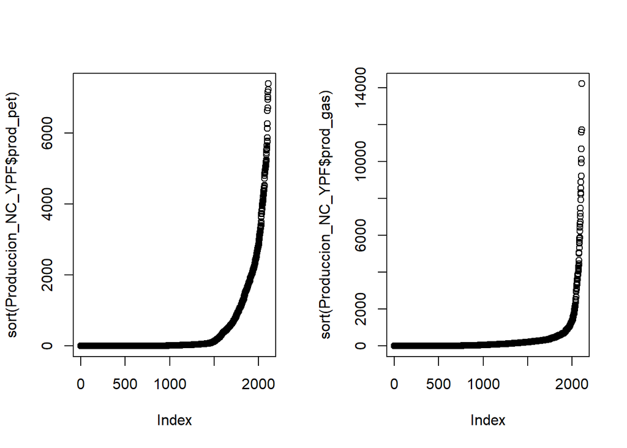

```r
par(mfcol=c(1,2))
plot(sort(Produccion_NC_YPF$prod_pet))
plot(sort(Produccion_NC_YPF$prod_gas))
```

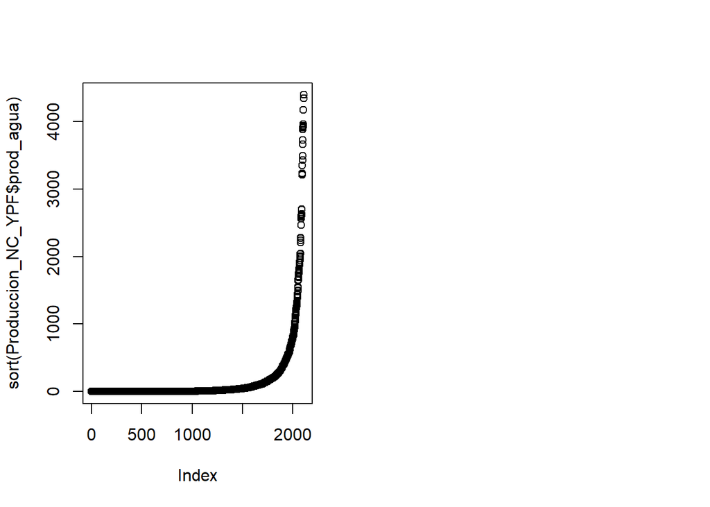

```r
plot(sort(Produccion_NC_YPF$prod_agua))
```

*Comparacion de variables*

producción de gas vs produccion de petróleo:

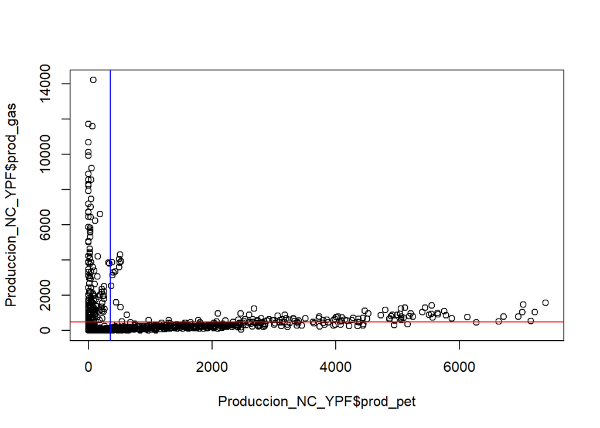

```r
plot(Produccion_NC_YPF$prod_pet,Produccion_NC_YPF$prod_gas)
abline(h=prom_pet, col="red")
abline(v=prom_gas, col="blue")
```

## Profundidad de los Pozos

```r
summary(datos$profundidad)
```

```
##    Min. 1st Qu.  Median    Mean 3rd Qu.    Max.
##       0    3045    3838    3936    5124    7784
```

Si bien es un dato relativo, porque mucho de los pozos son horizontales, se podria desprender de estos valores que el promedio de profundiad de los pozos es de 3935m. El máximo valor corresponde a 7784 (porque el valor se interpreta que incluye el tramo horizontal) y que los pozos con valor de profundiad 0 son los que no tienen cargados estos datos en el dataset.

- representación Gráfica de las profundidades

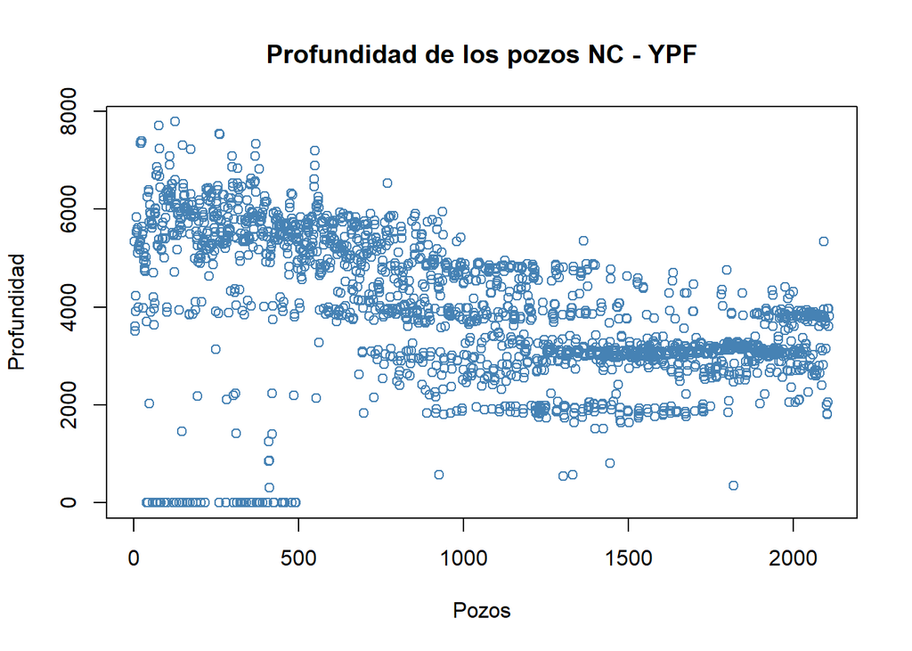

```r
plot(datos$profundidad,  col='steelblue', xlab = 'Pozos', ylab = 'Profundidad', main = "Profundidad de los pozos NC - YPF")
```

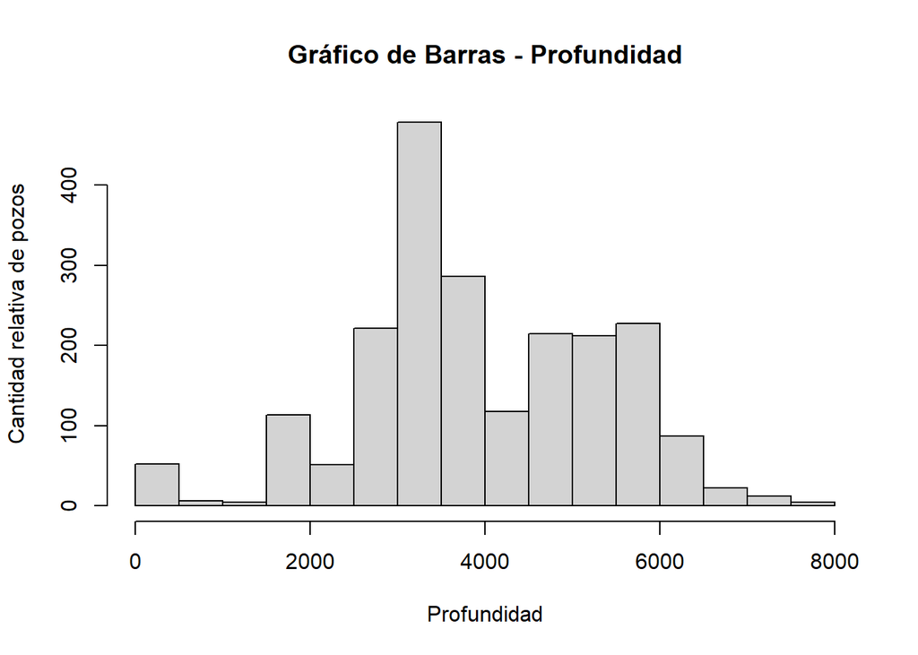

```r
hist(profundidad,  main = "Gráfico de Barras - Profundidad", ylab="Cantidad relativa de pozos",xlab="Profundidad")
```

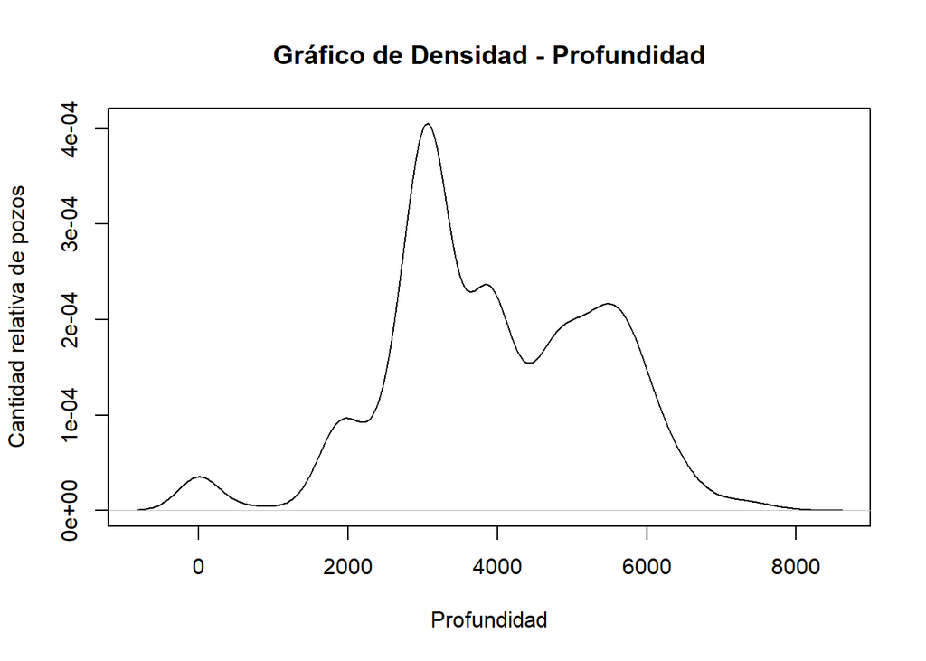

```r
Densidad <- density(profundidad)

plot(density(profundidad), main = "Gráfico de Densidad - Profundidad", ylab="Cantidad relativa de pozos",xlab="Profundidad")
```

Podemos llegar a la conclusion que la profundidad que la mayor profundidad reflejada de los pozos estan entre los 2000 y 6000 metros

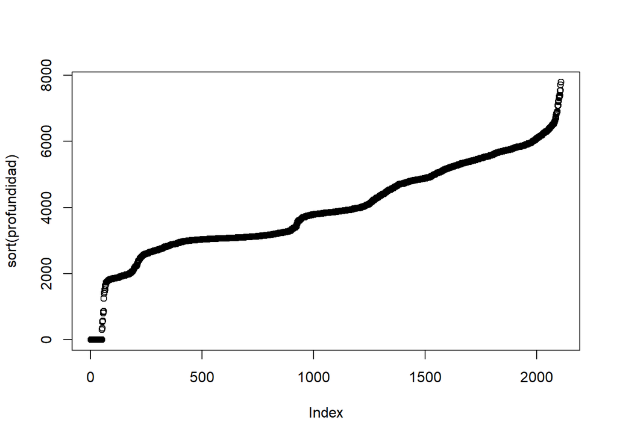

```r
plot(sort(profundidad))
```

## Representación geográfica de los pozos

Presentamos las distintas areas concecionadas y la cantidad de pozos que le corresponden:

```r
data.frame(AGUADA_DE_LA_ARENA, AGUADA_DEL_CHANAR, AL_NORTE_DE_LA_DORSA, BAJO_DEL_TORO, BAJO_DEL_TORO_NORTE, BANDURRIA_SUR, CERRO_ARENA, CERRO_LAS_MINAS, CERRO_MANRIQUE, CHIUIDO_DE_LA_SIERRA_NEGRAS, CN_VII_A, DADIN, EL_OREJANO, ESTACION_FERNADEZ_ORO, FILO_MORADO, LA_AMARGA_CHICA, LA_RIBERA_BLOQUE_I, LA_RIBERA_BLOQUE_II, LAS_MANADAS, LAS_TACANAS, LOMA_AMARILLA_SUR, LOMA_CAMPANA, LOMA_DEL_MOLLE, LOMA_LA_LATA_SIERRA_BARROSA, LOS_CALDENES, OCTOGONO, PASO_DE_LAS_BARDAS_NORTE, RINCON_DEL_MANGRULLO, RIO_NEUQUEN, VALLE_DEL_RIO_GRANDE)
```

```
##   AGUADA_DE_LA_ARENA AGUADA_DEL_CHANAR AL_NORTE_DE_LA_DORSA BAJO_DEL_TORO
## 1                 34                18                   40             2
##   BAJO_DEL_TORO_NORTE BANDURRIA_SUR CERRO_ARENA CERRO_LAS_MINAS CERRO_MANRIQUE
## 1                  16           108           4               1              1
##   CHIUIDO_DE_LA_SIERRA_NEGRAS CN_VII_A DADIN EL_OREJANO ESTACION_FERNADEZ_ORO
## 1                           0        1     2         94                     0
##   FILO_MORADO LA_AMARGA_CHICA LA_RIBERA_BLOQUE_I LA_RIBERA_BLOQUE_II
## 1           2               0                 20                   1
##   LAS_MANADAS LAS_TACANAS LOMA_AMARILLA_SUR LOMA_CAMPANA LOMA_DEL_MOLLE
## 1           3           3                 5          775              2
##   LOMA_LA_LATA_SIERRA_BARROSA LOS_CALDENES OCTOGONO PASO_DE_LAS_BARDAS_NORTE
## 1                           0            4       13                        4
##   RINCON_DEL_MANGRULLO RIO_NEUQUEN VALLE_DEL_RIO_GRANDE
## 1                  189         111                    1
```

**determinamos la cantidad de areas**

que corresponde a la cantidad de:

```r
# Determinar la cantidad Se designa una variable "cantidad_area" para contabilizar

Areas <- c(data.frame(AGUADA_DE_LA_ARENA, AGUADA_DEL_CHANAR, AL_NORTE_DE_LA_DORSA, BAJO_DEL_TORO, BAJO_DEL_TORO_NORTE, BANDURRIA_SUR, CERRO_ARENA, CERRO_LAS_MINAS, CERRO_MANRIQUE, CHIUIDO_DE_LA_SIERRA_NEGRAS, CN_VII_A, DADIN, EL_OREJANO, ESTACION_FERNADEZ_ORO, FILO_MORADO, LA_AMARGA_CHICA, LA_RIBERA_BLOQUE_I, LA_RIBERA_BLOQUE_II, LAS_MANADAS, LAS_TACANAS, LOMA_AMARILLA_SUR, LOMA_CAMPANA, LOMA_DEL_MOLLE, LOMA_LA_LATA_SIERRA_BARROSA, LOS_CALDENES, OCTOGONO, PASO_DE_LAS_BARDAS_NORTE, RINCON_DEL_MANGRULLO, RIO_NEUQUEN, VALLE_DEL_RIO_GRANDE))

cantidad_areas <- c(Areas)
length (cantidad_areas)
```

```
## [1] 30
```

**Determinamos la cantidad de pozos por provincias**

```r
data.frame(Neuquen, Rio_Negro, Mendoza)
```

```
##   Neuquen Rio_Negro Mendoza
## 1    1898       204       6
```

## MAPA INTERACTIVO

ploteo simple de las coordenadas para poder comparar con los resultados de la parte geográfica de este trabajo:

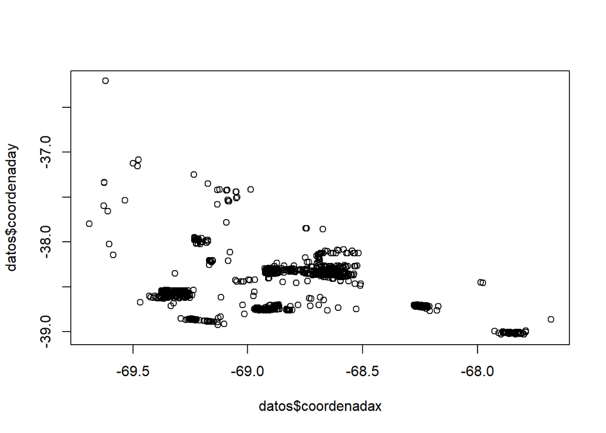

```r
plot(datos$coordenadax, datos$coordenaday)
```

```r
inventario <- read_delim("Produccion NC YPF.csv",
    delim = ";", escape_double = FALSE, col_types = cols(prod_gas = col_double(),
        coordenadax = col_number(), coordenaday = col_number()),
    trim_ws = TRUE)


puntos <- data.frame(inventario)
```

```r
# PASO 2. Realizar clustering con k-means
set.seed(123) # Para reproducibilidad
kmeans_result <- kmeans(puntos[, c('coordenadax','coordenaday')], centers = 4)
```

```r
# PASO 3. Añadir la clasificación de clusters al inventario
inventario$cluster <- kmeans_result$cluster
```

```r
# PASO 4. Convertir a un objeto sf para poder graficar en un mapa
inventario_sf <- st_as_sf(inventario, coords = c('coordenadax', 'coordenaday'), crs = 4326)
```

```r
# PASO 5. Obtener el mapa de Argentina
argentina_map <- st_as_sf(maps::map('world', 'argentina', plot = FALSE, fill = TRUE))
```

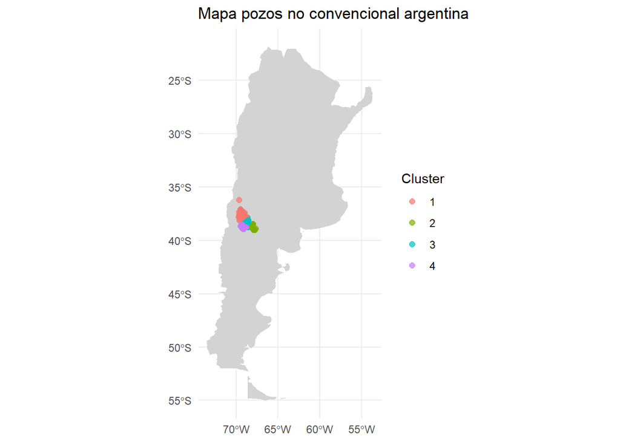

```r
# PASO 6. Graficar un mapa con los clusters (MApa sencillo)
ggplot() +
  geom_sf(data = argentina_map, fill = 'lightgrey', color = 'white') +
  geom_sf(data = inventario_sf, aes(color = factor(cluster)), size = 2, alpha = 0.7) +
  labs(color = 'Cluster') +
  theme_minimal() +
  ggtitle('Mapa pozos no convencional argentina')
```

```r
# PASO 7. Crear un mapa interactivo con leaflet

mapa <- leaflet(inventario) %>%
  addTiles() %>%
  addCircleMarkers(lng = ~coordenaday, lat = ~coordenadax, popup = ~as.character(cluster), color = ~factor(cluster), clusterOptions = markerClusterOptions()) %>%
  addProviderTiles(providers$CartoDB.Positron)
```

```r
## PASO 8. Creacion de un Mapa Georeferenciado

activos <- data.frame(
  lat = puntos$coordenaday,
  long = puntos$coordenadax,
    stringsAsFactors = FALSE
)
```

```r
## PASO 9. convierte la codificación de un vector de caracteres de una codificación a otra.


leaflet(data = activos[1:299, ]) %>%
  addTiles() %>%
  addMarkers(
    lng = ~long,
    lat = ~lat, )
```

[interactive chart not shown]

# Conclusion y discusión final

El desarrollo de este trabajo implico la colaboracion del grupo y la interpretacion de datos como su analisis y manipulacion. de esta manera adquirimos experiencia tanto en el area de investigacion, analisis de datos y programación en R.

# Figuras, Tablas y esquemas

tabla 1 - Data set, Produccion de HC no convencional YPF Marzo 2024

```r
datos
```

```
## # A tibble: 2,108 × 29
##    idempresa  anio   mes idpozo prod_pet prod_gas prod_agua   tef tipoextraccion
##    <chr>     <dbl> <dbl>  <dbl>    <dbl>    <dbl>     <dbl> <dbl> <chr>
##  1 YPF        2024     3  75605     0         0        0        0 Plunger Lift
##  2 YPF        2024     3  75604     0         0        0        0 Plunger Lift
##  3 YPF        2024     3  72233    10.6     208.       0       31 Surgencia Nat…
##  4 YPF        2024     3  72232     9.84    427.      43.3     31 Surgencia Nat…
##  5 YPF        2024     3  72228     1.98     46.2      5.05    30 Surgencia Nat…
##  6 YPF        2024     3  72206     0         0        0        0 Surgencia Nat…
##  7 YPF        2024     3 165188   198.       21.5    650.       8 Surgencia Nat…
##  8 YPF        2024     3 165187   409.       43.4    665.       8 Surgencia Nat…
##  9 YPF        2024     3 165186   145.       13.5    674.       8 Surgencia Nat…
## 10 YPF        2024     3 165185   285.       28.8    525.       8 Surgencia Nat…
## # ℹ 2,098 more rows
## # ℹ 20 more variables: tipoestado <chr>, tipopozo <chr>, idusuario <dbl>,
## #   empresa <chr>, sigla <chr>, formprod <chr>, profundidad <dbl>,
## #   formacion <chr>, idareapermisoconcesion <chr>, areapermisoconcesion <chr>,
## #   idareayacimiento <chr>, areayacimiento <chr>, cuenca <chr>,
## #   provincia <chr>, coordenadax <dbl>, coordenaday <dbl>,
## #   tipo_de_recurso <chr>, clasificacion <chr>, subclasificacion <chr>, …
```

tabla 2 - produccion de pozos por tipo de estado.

```r
dataf_tipoestado
```

```
##                              TipoEstado  ProdGas ProdPet
## 1                            En Estudio     0.00    0.00
## 2               Parado Transitoriamente     0.00    0.00
## 3                   Extraccion Efectiva   208.12   10.65
## 4                   Extraccion Efectiva   427.42    9.84
## 5                   Extraccion Efectiva    46.16    1.98
## 6               En Espera de Reparacion     0.00    0.00
## 7                   Extraccion Efectiva    21.46  198.38
## 8                   Extraccion Efectiva    43.39  409.14
## 9                   Extraccion Efectiva    13.49  144.94
## 10                  Extraccion Efectiva    28.78  284.70
## 11                  Extraccion Efectiva    26.55  436.76
## 12                  Extraccion Efectiva    21.15  297.69
## 13                  Extraccion Efectiva  6597.70  191.78
## 14                  Extraccion Efectiva     3.30   24.59
```

[output cut: 2094 more lines]

tabla 3 - extraccion efectiva

```r
ExtraccionEfectiva
```

```
##               TipoEstado  ProdGas ProdPet
## 3    Extraccion Efectiva   208.12   10.65
## 4    Extraccion Efectiva   427.42    9.84
## 5    Extraccion Efectiva    46.16    1.98
## 7    Extraccion Efectiva    21.46  198.38
## 8    Extraccion Efectiva    43.39  409.14
## 9    Extraccion Efectiva    13.49  144.94
## 10   Extraccion Efectiva    28.78  284.70
## 11   Extraccion Efectiva    26.55  436.76
## 12   Extraccion Efectiva    21.15  297.69
## 13   Extraccion Efectiva  6597.70  191.78
## 14   Extraccion Efectiva     3.30   24.59
## 15   Extraccion Efectiva     4.43   33.02
## 16   Extraccion Efectiva     3.30   24.60
## 17   Extraccion Efectiva     8.47   68.90
```

[output cut: 1643 more lines]

# Patents